# Basketball Exploration

Bonnie LT Green

22 February 2017

## Basketball Exploration

Using a dataset downloaded from https://www.superdatascience.com/rcourse/, I will be exploring the stats of the top ten highest paid basketball players in the USA over the years 2005-2014, looking for trends.

# Overall Player Accuracy

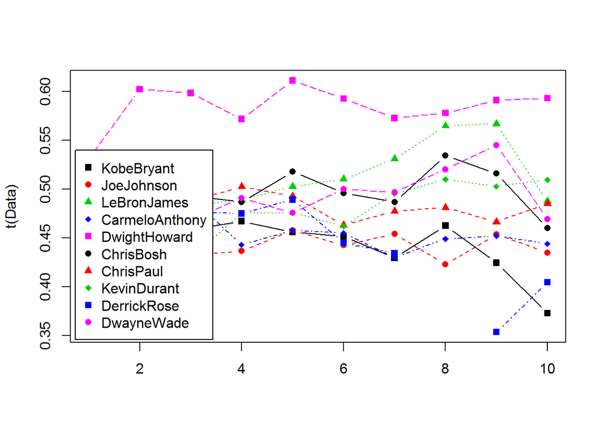

From this data, we have an excellent idea of the overall player accuracy - I’ve divided the number of times a successful field goal was scored by the number of attempts and we can see that Dwight Howard leads the pack, with the highest paid player Kobe Bryant’s accuracy trending radically downwardsto around 37%. What could be causing this?

First, I’m going to look into the data itself, and then into the players. My hypothesis is that Dwight Howard has a higher accuracy because the other players make more - and potentially riskier - shots, lowering their chances of scoring.

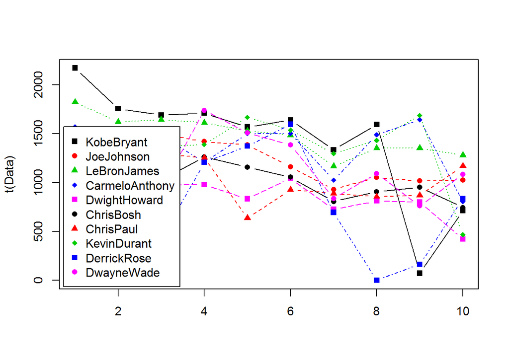

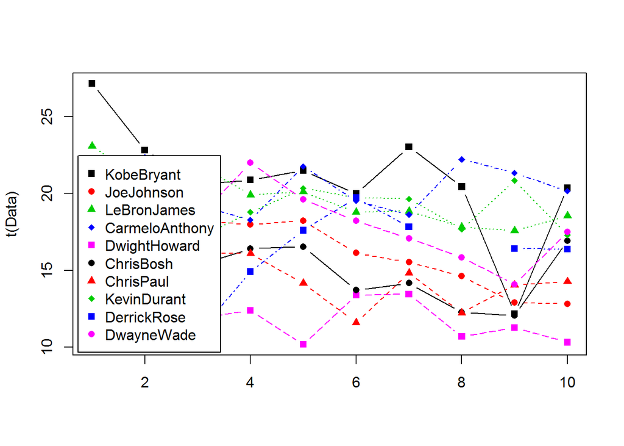

If we compare field goal attempts per game to accuracy, we can see that Dwight Howard tends to make the fewest attempts; in fact, only one player has made fewer attempts by him, and that was during a single season.

So why does Dwight Howard make so few attempts to score? Dwight Howard plays Center, a role that’s primarily defensive.

# So what about player style?

It’s one thing to explore accuracy. Another valuable component of any player is their style. What percentage of throws do each make that are 2-pointers or 3-pointers?

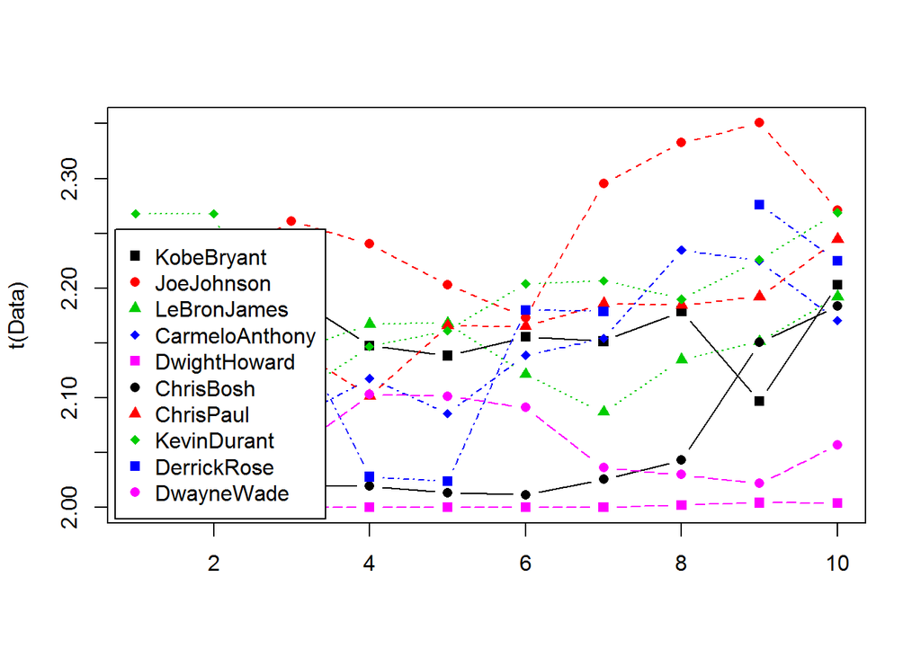

## Does the time a player is on the field correlate to their pay?

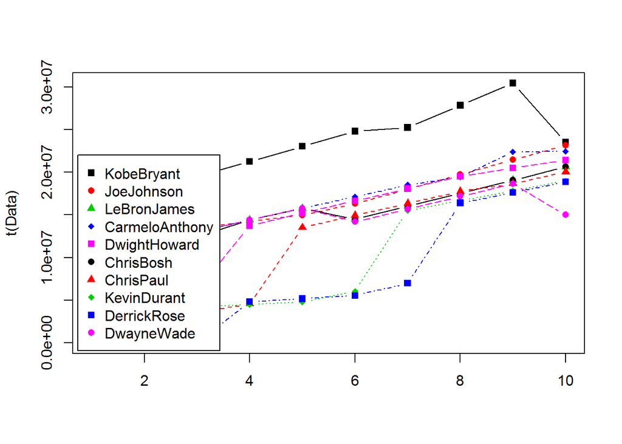

This is a chart of player salary over the past few seasons. Each player has trended upwards throughout their NBA careers, with Kobe Bryant having the highest salary by quite some margin. Is this due to an increase of time on the court or due to an increase of points gained for their respective teams?

First, let’s look at how much they get paid per minute on the court.

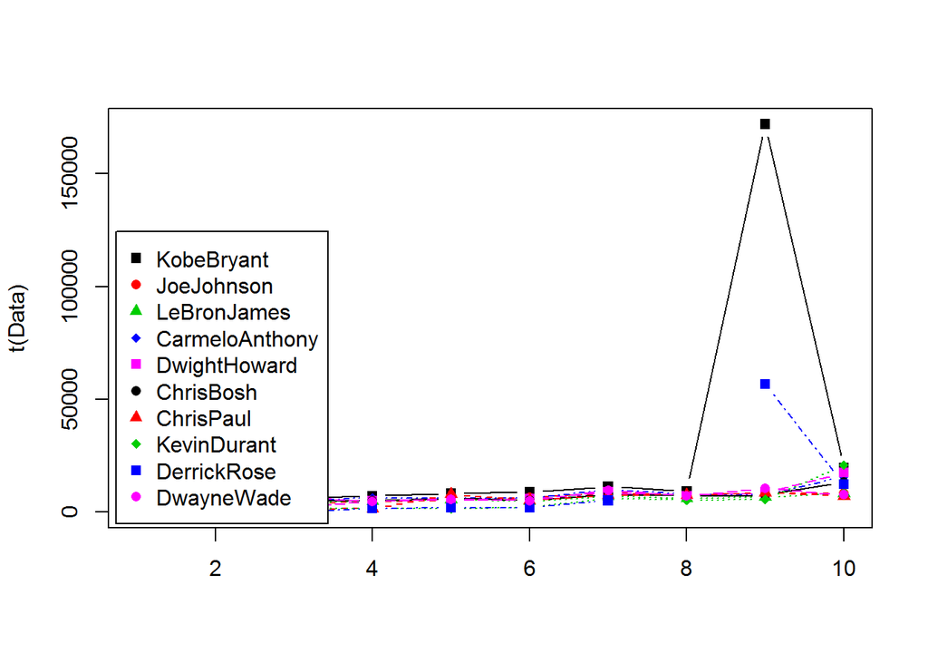

Wow! What could’ve caused those massive spikes for Kobe Bryant and Derrick Rose? Let’s look at Minutes Player per player separately:

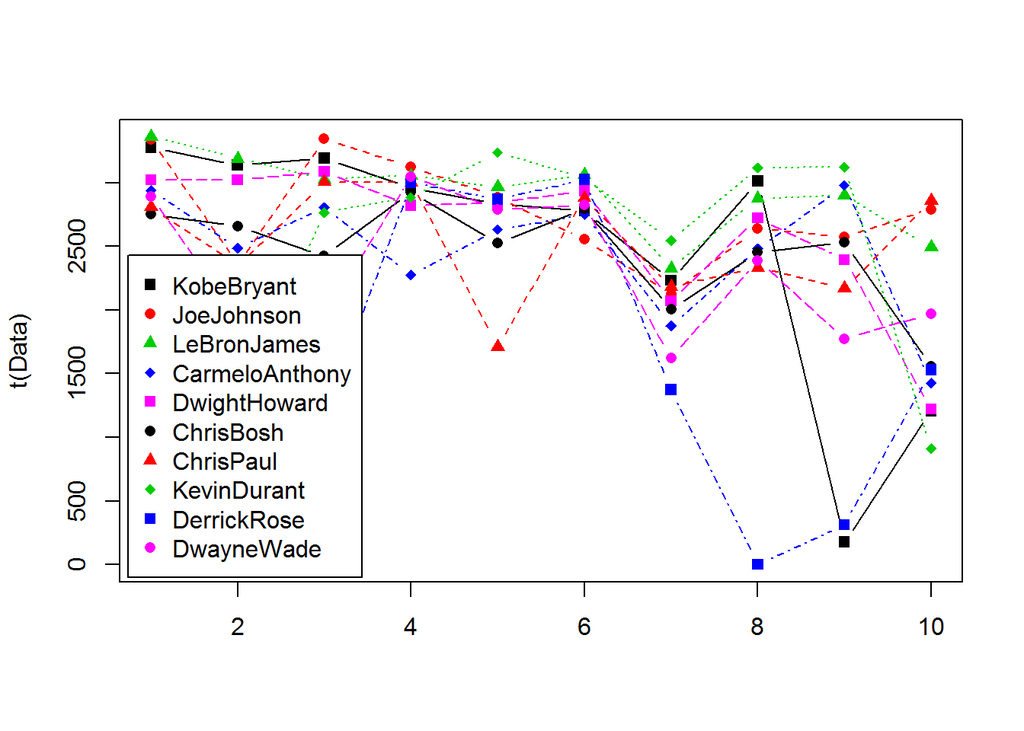

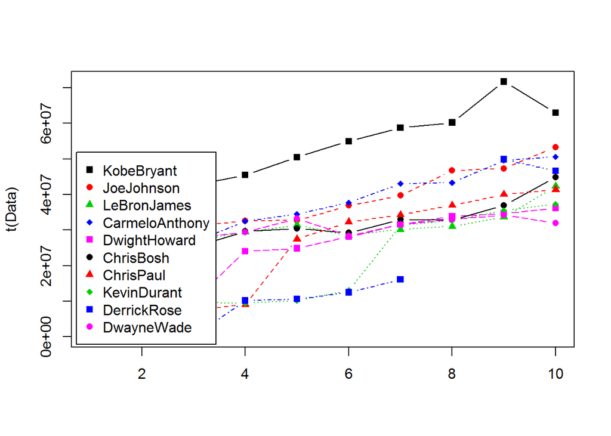

When we examine the salary over the field goal accuracy, we can see a general trend upwards, which correlates with the pay increases. I would also argue that the ‘brand name’ value of each player affects their pricing, but I do not currently have that data to explore.

In conclusion, Basketball is a weird sport and I do not understand its rules. But Kobe Bryant and Dwight Howard seem like awesome players.